# linear_models

Ayeshra Acharya

11/23/2020

Lm is linear models, glm for generalized lnear models Arguments include: formula, data Output is complex and kind of messy, use broom package! - Use broom after running LM

```r
data("nyc_airbnb")
nyc_airbnb =
  nyc_airbnb %>%
  mutate(stars = review_scores_location / 2) %>%
  rename(
    borough = neighbourhood_group,
    neighborhood = neighbourhood) %>%
  filter(borough != "Staten Island") %>%
  select(price, stars, borough, neighborhood, room_type)
```

## Fit a model. We want to know what is the price of an an airbnb rental and how is it related to star (numeric predictor) and borough(categorical predictor). Fir some line that runs through stars and maybe different for each borough.

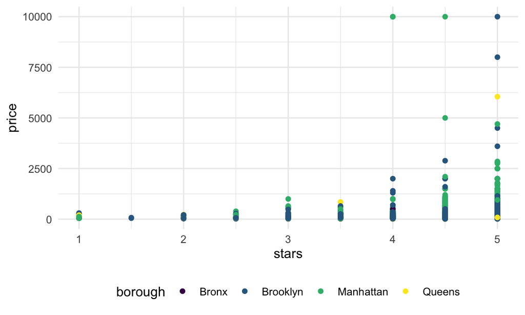

```r
nyc_airbnb %>%
  ggplot(aes(x = stars,y=price,color=borough)) +
  geom_point()
```

Let’s fit the model we care about. Linear model relating price to starts to borough.

```r
fit = lm(price ~ stars + borough, data = nyc_airbnb)
```

Let’s look at the result.. If you look at the summary you get way more, R squared, residuals etc. You can also get coefficients of the fit. There has been useful stuff that R has produced using “fit”, but it is not great. So we will use broom!

```r
broom::glance(fit)
```

```
## # A tibble: 1 x 12
##   r.squared adj.r.squared sigma statistic   p.value    df  logLik    AIC    BIC
##       <dbl>         <dbl> <dbl>     <dbl>     <dbl> <dbl>   <dbl>  <dbl>  <dbl>
## 1    0.0342        0.0341  182.      271. 6.73e-229     4 -2.02e5 4.04e5 4.04e5
## # … with 3 more variables: deviance <dbl>, df.residual <int>, nobs <int>
```

Here, we get the r-squared, we get p-value etc. This is some of the most relevant info. Global test p-value.

However, this below might be better.

```r
broom::tidy(fit)
```

```
## # A tibble: 5 x 5
##   term             estimate std.error statistic  p.value
##   <chr>               <dbl>     <dbl>     <dbl>    <dbl>
## 1 (Intercept)         -70.4     14.0      -5.02 5.14e- 7
## 2 stars                32.0      2.53     12.7  1.27e-36
## 3 boroughBrooklyn      40.5      8.56      4.73 2.23e- 6
## 4 boroughManhattan     90.3      8.57     10.5  6.64e-26
## 5 boroughQueens        13.2      9.06      1.46 1.45e- 1
```

This above is showing us: intercept, coefficient for stars, brooklyn to reference group, manhattan to reference group and queens to reference group. How to interpret: One unit increase in stars, I expect the price to go up 32 dollars, keeping the borough fixed. Brooklyn room airbnb is 40 dollars more expensive than Bronx. Manhattan is 90 dollars more expensive, Queens is 13 dollars more expensive. We can see p value and assess significance. - Remember, this is a data frame. If we aren’t interested in certain things, we can omit. For example:

```r
broom::tidy(fit) %>%
  select(-std.error,-statistic) %>%
  mutate(
    term = str_replace(term,"borough","Borough:")
  ) %>%
  knitr::kable()
```

| term | estimate | p.value |
| --- | --- | --- |
| (Intercept) | -70.41446 | 0.0000005 |
| stars | 31.98989 | 0.0000000 |
| Borough:Brooklyn | 40.50030 | 0.0000022 |
| Borough:Manhattan | 90.25393 | 0.0000000 |
| Borough:Queens | 13.20617 | 0.1451682 |

## Be in control of factors.

For example, borough is a character variable. Very often, this gets converted into a factor variable. You perserve text, but add another string… Idk but basically, Bronx is being used as the reference here. - But what if, I want to make reference category the most common one? SO, I want reference group to be the one that has the most airbnb rentals. I want room type to be treated as factor variable, not alphabetical but most common . Mutate so that borough is factor and we are putting it in order of frequency of borough.

```r
nyc_airbnb =
  nyc_airbnb %>%
  mutate(
    borough = fct_infreq(borough),
    room_type = fct_infreq(room_type)
  )
```

Now, let’s look at the plot again.

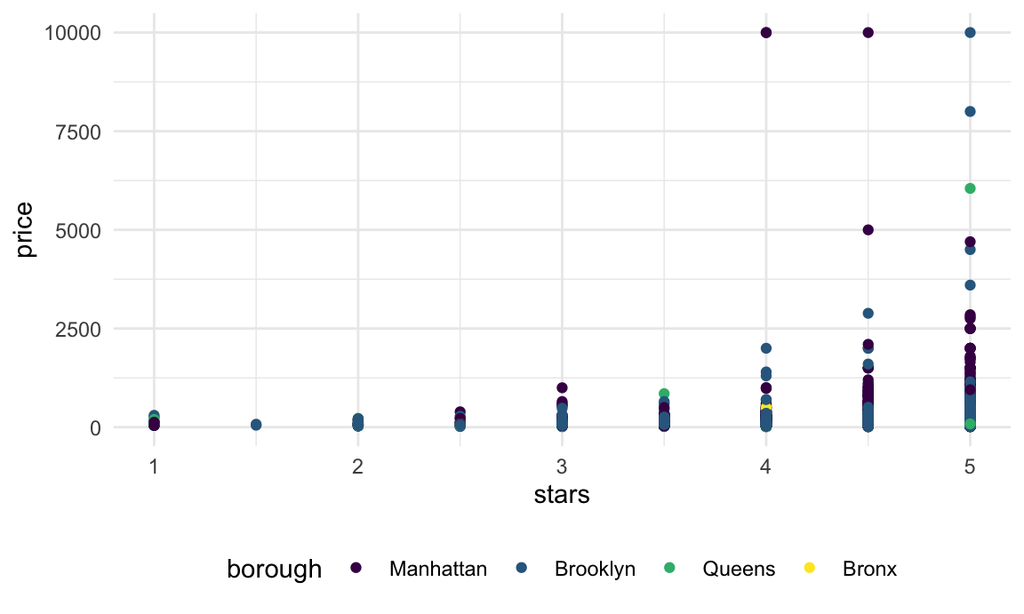

```r
nyc_airbnb %>%
  ggplot(aes(x=stars,y=price, color=borough)) +
  geom_point()
```

## Re fit the model

```r
fit = lm(price ~ stars + borough, data = nyc_airbnb)
broom::tidy(fit)
```

```
## # A tibble: 5 x 5
##   term            estimate std.error statistic   p.value
##   <chr>              <dbl>     <dbl>     <dbl>     <dbl>
## 1 (Intercept)         19.8     12.2       1.63 1.04e-  1
## 2 stars               32.0      2.53     12.7  1.27e- 36
## 3 boroughBrooklyn    -49.8      2.23    -22.3  6.32e-109
## 4 boroughQueens      -77.0      3.73    -20.7  2.58e- 94
## 5 boroughBronx       -90.3      8.57    -10.5  6.64e- 26
```

The difference now is that manhattan became the reference group and everythig else is being compared to it. We didn’t change model in a fundamental way, we changed the reference group.

## Diagnostics

```r
residuals(fit)
```

[output not shown]

[output cut: 12157 more lines]

[output not shown]

Up until now we have been using the above approach. We get super long vector. we want to get all variables and then tack onto that fitted variables that go along with it. So we will take advantage of modelr package.

```r
modelr::add_residuals(nyc_airbnb,fit)
```

```
## # A tibble: 40,492 x 6
##    price stars borough neighborhood room_type        resid
##    <dbl> <dbl> <fct>   <chr>        <fct>            <dbl>
##  1    99   5   Bronx   City Island  Private room      9.47
##  2   200  NA   Bronx   City Island  Private room     NA
##  3   300  NA   Bronx   City Island  Entire home/apt  NA
##  4   125   5   Bronx   City Island  Entire home/apt  35.5
##  5    69   5   Bronx   City Island  Private room    -20.5
##  6   125   5   Bronx   City Island  Entire home/apt  35.5
##  7    85   5   Bronx   City Island  Entire home/apt  -4.53
##  8    39   4.5 Bronx   Allerton     Private room    -34.5
##  9    95   5   Bronx   Allerton     Entire home/apt   5.47
## 10   125   4.5 Bronx   Allerton     Entire home/apt  51.5
## # … with 40,482 more rows
```

This dataset has a column for residual value. Residuals based on model fit. We can look at distributions of residuals, for instance.

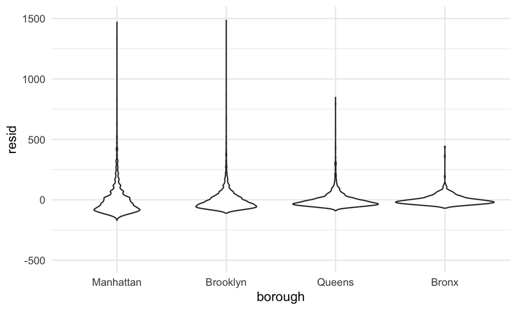

```r
nyc_airbnb %>%
  modelr::add_residuals(fit) %>%
  ggplot(aes(x=borough,y=resid)) +
  geom_violin() +
  ylim(-500,1500)
```

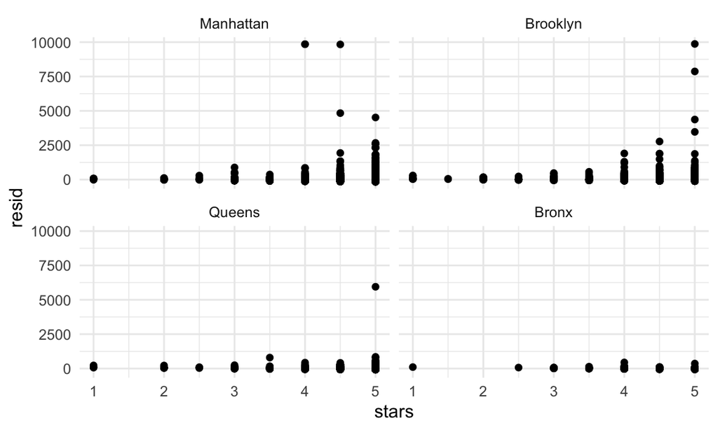

```r
nyc_airbnb %>%
  modelr::add_residuals(fit) %>%
  ggplot(aes(x=stars,y=resid)) +
  geom_point() +
  facet_wrap(.~ borough)
```

What is this telling us?? In Manhattan, as we get to higher star values, residuals get wider distributions. 4 5 stars in Manhattan, distribution of residuals in Manhattan gets higher. Same in Brooklyn. Why does Queens have one outlier?? Bronx doesn’t have this issue

## Hypothesis Tests

```r
fit %>%
  broom::tidy()
```

```
## # A tibble: 5 x 5
##   term            estimate std.error statistic   p.value
##   <chr>              <dbl>     <dbl>     <dbl>     <dbl>
## 1 (Intercept)         19.8     12.2       1.63 1.04e-  1
## 2 stars               32.0      2.53     12.7  1.27e- 36
## 3 boroughBrooklyn    -49.8      2.23    -22.3  6.32e-109
## 4 boroughQueens      -77.0      3.73    -20.7  2.58e- 94
## 5 boroughBronx       -90.3      8.57    -10.5  6.64e- 26
```

If we have categorical predictor, we want to know if categorical predictor as a whole is significant in my model.

What about the significance of borough? we can do f test or ANOVA. adding borough into one model to compare

```r
fit_null = lm(price ~ stars, data = nyc_airbnb)
fit_alt = lm(price ~ stars + borough, data = nyc_airbnb)

anova(fit_null,fit_alt)
```

```
## Analysis of Variance Table
##
## Model 1: price ~ stars
## Model 2: price ~ stars + borough
##   Res.Df        RSS Df Sum of Sq      F    Pr(>F)
## 1  30528 1030861841
## 2  30525 1005601724  3  25260117 255.59 < 2.2e-16 ***
## ---
## Signif. codes:  0 '***' 0.001 '**' 0.01 '*' 0.05 '.' 0.1 ' ' 1
```

```r
broom::tidy()
```

```
## # A tibble: 0 x 0
```

## Nest data, fit models

Is there an association between price and stars? Does this association differ by borough? - We want different lines for each borough? - Can also study across room type. - We can fit interaction terms! Interactions are important, and complicated.

```r
fit = lm(price ~ stars * borough + room_type * borough, data = nyc_airbnb)
broom::tidy(fit)
```

```
## # A tibble: 16 x 5
##    term                                  estimate std.error statistic  p.value
##    <chr>                                    <dbl>     <dbl>     <dbl>    <dbl>
##  1 (Intercept)                              95.7      19.2     4.99   6.13e- 7
##  2 stars                                    27.1       3.96    6.84   8.20e-12
##  3 boroughBrooklyn                         -26.1      25.1    -1.04   2.99e- 1
##  4 boroughQueens                            -4.12     40.7    -0.101  9.19e- 1
##  5 boroughBronx                             -5.63     77.8    -0.0723 9.42e- 1
##  6 room_typePrivate room                  -124.        3.00  -41.5    0.
##  7 room_typeShared room                   -154.        8.69  -17.7    1.42e-69
##  8 stars:boroughBrooklyn                    -6.14      5.24   -1.17   2.41e- 1
##  9 stars:boroughQueens                     -17.5       8.54   -2.04   4.09e- 2
## 10 stars:boroughBronx                      -22.7      17.1    -1.33   1.85e- 1
## 11 boroughBrooklyn:room_typePrivate room    32.0       4.33    7.39   1.55e-13
## 12 boroughQueens:room_typePrivate room      54.9       7.46    7.37   1.81e-13
## 13 boroughBronx:room_typePrivate room       71.3      18.0     3.96   7.54e- 5
## 14 boroughBrooklyn:room_typeShared room     47.8      13.9     3.44   5.83e- 4
## 15 boroughQueens:room_typeShared room       58.7      17.9     3.28   1.05e- 3
## 16 boroughBronx:room_typeShared room        83.1      42.5     1.96   5.03e- 2
```

First row: overall, stars has this effect. Then, we get it for each as we go down the rows. Looks like stars increasing does make a difference.

If you wanted to assess statistical sig, you can compare 1 fit that has itneraction and another that doesn’t and ask if that’s an improvement in model. Is it important contributor?

This is more exploratory but maybe easier to understand. What is the effect of sstars in Manhattan, stars in BK, stars in Bronx? Build up from scratch a bit. Results columns maps across columns. In this we are fitting a model to each borough. Broom tidying is tidying all.

```r
nyc_airbnb %>%
  nest(data = -borough) %>%
  mutate(
    models = map(.x = data, ~lm(price ~ stars, data = .x)),
    results = map(models,broom::tidy)
  ) %>%
  select(-data,-models) %>%
  unnest(results)
```

```
## # A tibble: 8 x 6
##   borough   term        estimate std.error statistic  p.value
##   <fct>     <chr>          <dbl>     <dbl>     <dbl>    <dbl>
## 1 Bronx     (Intercept)    49.9      18.3      2.72  6.71e- 3
## 2 Bronx     stars           4.91      4.10     1.20  2.31e- 1
## 3 Queens    (Intercept)    18.1      26.3      0.688 4.92e- 1
## 4 Queens    stars          15.8       5.63     2.81  5.06e- 3
## 5 Brooklyn  (Intercept)   -11.3      14.5     -0.784 4.33e- 1
## 6 Brooklyn  stars          28.0       3.10     9.02  2.13e-19
## 7 Manhattan (Intercept)   -34.3      22.9     -1.50  1.35e- 1
## 8 Manhattan stars          43.3       4.78     9.07  1.39e-19
```

As we can see from above, in Manhattan, there is a sig association between stars and price. 1 unit increase in stars = 43 dollar increase. In Bronx theres hardly any association between stars and price. We can’t say anything about whether models are different than each other bc we didn’t fit this all in a join model. This is more exploratory.

```r
nyc_airbnb %>%
  nest(data = -borough) %>%
  mutate(
    models = map(.x = data, ~lm(price ~ stars, data = .x)),
    results = map(models,broom::tidy)
  ) %>%
  select(-data,-models) %>%
  unnest(results) %>%
  filter(term != "(Intercept)") %>%
  select(borough,term,estimate) %>%
  pivot_wider(
    names_from = borough,
    values_from = estimate
  )
```

```
## # A tibble: 1 x 5
##   term  Bronx Queens Brooklyn Manhattan
##   <chr> <dbl>  <dbl>    <dbl>     <dbl>
## 1 stars  4.91   15.8     28.0      43.3
```

Let’s nest even more. What if we wanted to look at neighborhoods within Manhattan? Getting a separate model for each of the 32 neighborhoods in Manhattan.

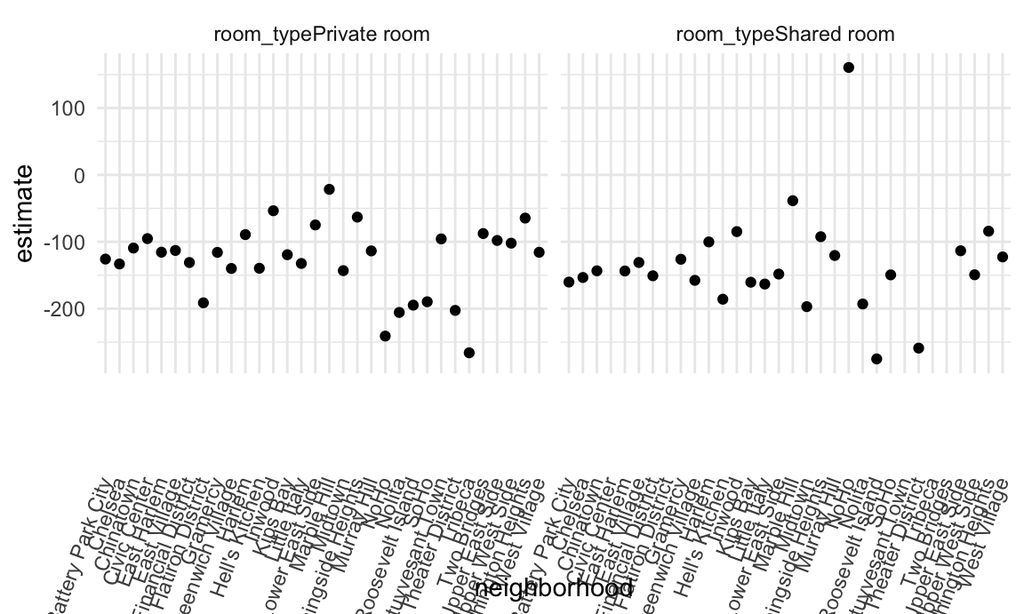

```r
nyc_airbnb %>%
  filter(borough == "Manhattan") %>%
  nest(data = -neighborhood) %>%
  mutate(
    models = map(.x = data, ~lm(price ~ stars + room_type, data = .x)),
    results = map(models,broom::tidy)
  ) %>%
  select(-data,-models) %>%
  unnest(results) %>%
  filter(str_detect(term,"room_type")) %>%
  ggplot(aes(x = neighborhood, y = estimate)) +
  geom_point() +
  facet_wrap(. ~ term) +
  theme(axis.text.x = element_text(angle = 70, vjust = 0.5, hjust =1))
```

It worked!